# Time-dependent GeoTox

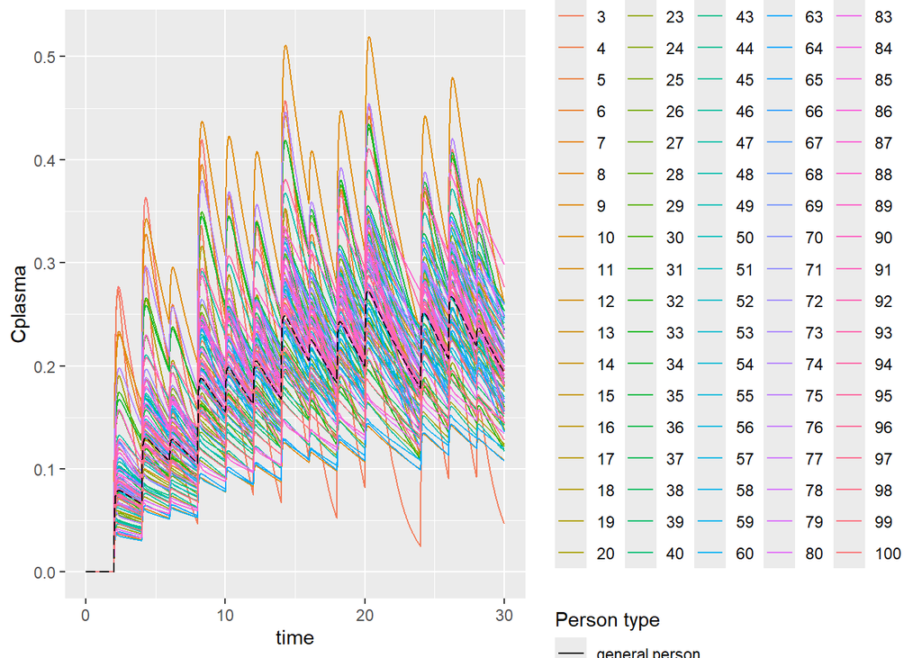

```r
periodic_standard_variability$`2`$plasma_plot
```

And the constant scenario.

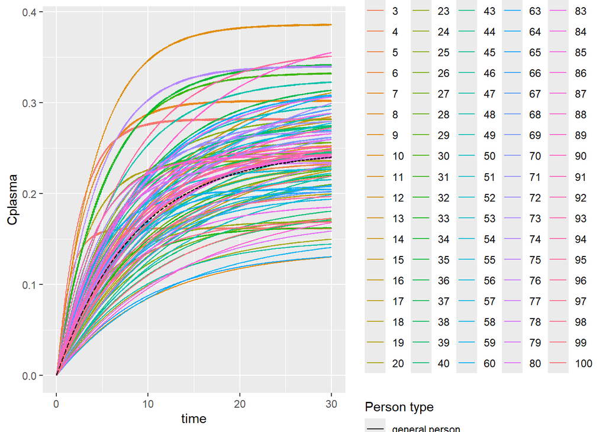

```r
constant_standard_variability$`0.1`$plasma_plot
```

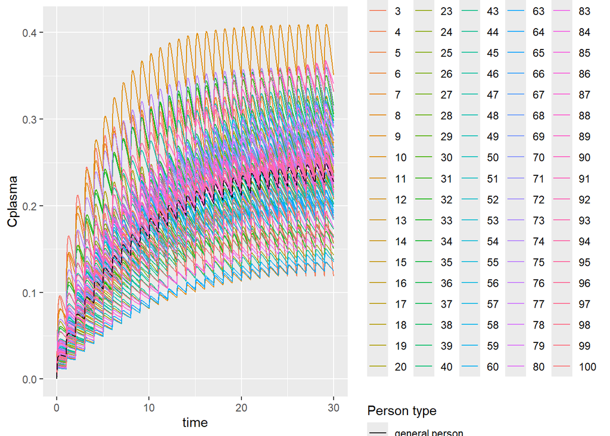

```r
constant_standard_variability$`1`$plasma_plot
```

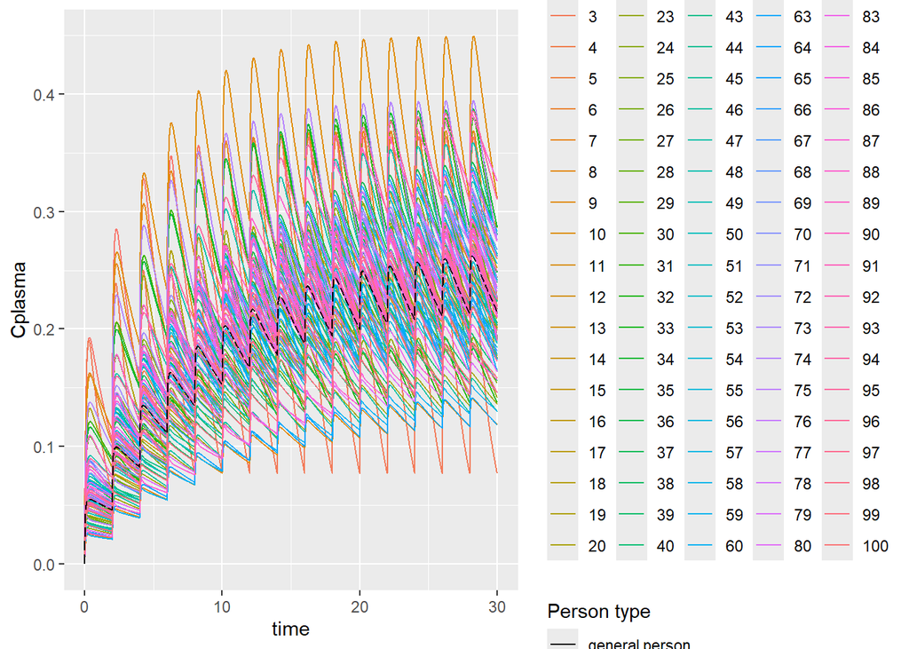

```r
constant_standard_variability$`2`$plasma_plot
```

We can dig further into the data by looking at the AUC of each person in each time resolution and exposure scenario. We compare with the original run without time resolution modification.

First for the acute scenario.

```r
summary(sapply(acute_standard_variability$`0.1`$numeric, function(t) {max(t$AUC)}))
```

```
##    Min. 1st Qu.  Median    Mean 3rd Qu.    Max.
##   3.990   6.425   7.498   7.458   8.481  11.970
```

```r
summary(sapply(acute_standard_variability$`1`$numeric, function(t) {max(t$AUC)}))
```

```
##    Min. 1st Qu.  Median    Mean 3rd Qu.    Max.
##   6.118   9.842  11.490  11.425  12.990  18.310
```

```r
summary(sapply(acute_standard_variability$`2`$numeric, function(t) {max(t$AUC)}))
```

```
##    Min. 1st Qu.  Median    Mean 3rd Qu.    Max.
##   3.274   5.269   6.157   6.124   6.955   9.846
```

```r
summary(sapply(simulation_acute_standard_average$numeric, function(t) {max(t$AUC)}))
```

```
##    Min. 1st Qu.  Median    Mean 3rd Qu.    Max.
##   3.937   6.340   7.400   7.360   8.369  11.820
```

The periodic scenario.

```r
summary(sapply(periodic_standard_variability$`0.1`$numeric, function(t) {max(t$AUC)}))
```

```
##    Min. 1st Qu.  Median    Mean 3rd Qu.    Max.
##   2.784   4.623   5.464   5.516   6.272   9.909
```

```r
summary(sapply(periodic_standard_variability$`1`$numeric, function(t) {max(t$AUC)}))
```

```
##    Min. 1st Qu.  Median    Mean 3rd Qu.    Max.
##   2.769   4.595   5.431   5.483   6.230   9.836
```

```r
summary(sapply(periodic_standard_variability$`2`$numeric, function(t) {max(t$AUC)}))
```

```
##    Min. 1st Qu.  Median    Mean 3rd Qu.    Max.
##   2.746   4.528   5.380   5.431   6.168   9.728
```

```r
summary(sapply(simulation_periodic_standard_average$numeric, function(t) {max(t$AUC)}))
```

```
##    Min. 1st Qu.  Median    Mean 3rd Qu.    Max.
##   2.783   4.620   5.460   5.513   6.268   9.903
```

And finally for the constant scenario.

```r
summary(sapply(constant_standard_variability$`0.1`$numeric, function(t) {max(t$AUC)}))
```

```
##    Min. 1st Qu.  Median    Mean 3rd Qu.    Max.
##   2.777   4.611   5.449   5.502   6.256   9.885
```

```r
summary(sapply(constant_standard_variability$`1`$numeric, function(t) {max(t$AUC)}))
```

```
##    Min. 1st Qu.  Median    Mean 3rd Qu.    Max.
##   2.835   4.704   5.553   5.609   6.369  10.050
```

```r
summary(sapply(constant_standard_variability$`2`$numeric, function(t) {max(t$AUC)}))
```

```
##    Min. 1st Qu.  Median    Mean 3rd Qu.    Max.
##   2.897   4.766   5.669   5.723   6.497  10.230
```

```r
summary(sapply(simulation_constant_standard_average$numeric, function(t) {max(t$AUC)}))
```

```
##    Min. 1st Qu.  Median    Mean 3rd Qu.    Max.
##   2.773   4.604   5.442   5.495   6.248   9.874
```

We also examine the effects of varying the time resolution on the mixture sensitivity.

```r
time_resolution_mixture_response <- compute_time_resolution_sensitivity(chem.cas = c('87-86-5', '80-05-7'), C_ext = mixture_c_ext, model_parameters = pbtk_param, hill_params = hill_params_mix, IR = 1, resolutions = c(.1, 1, 2), sample = 'left')
```

```
## [1] "87-86-5" "80-05-7"
## [1] "time"    "87-86-5" "80-05-7"
## [1] "80-05-7" "87-86-5"
## [1] "87-86-5" "80-05-7"
```

```
## [1] "87-86-5" "80-05-7"
## [1] "time"    "87-86-5" "80-05-7"
## [1] "80-05-7" "87-86-5"
## [1] "87-86-5" "80-05-7"
```

```
## [1] "87-86-5" "80-05-7"
## [1] "time"    "87-86-5" "80-05-7"
## [1] "80-05-7" "87-86-5"
## [1] "87-86-5" "80-05-7"
```

We examine the results.

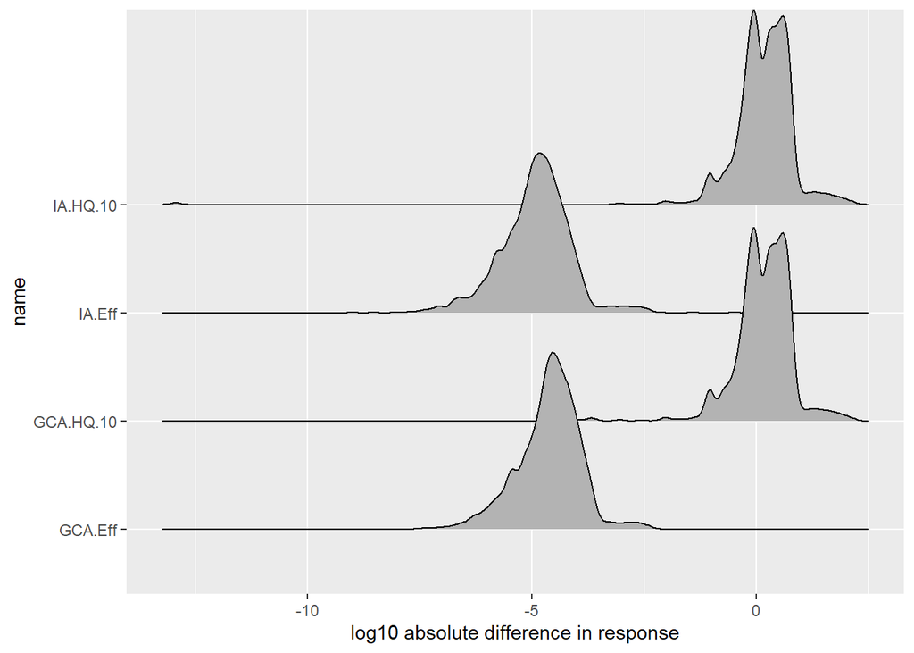

```r
# For the 0.1 day resolution
ggplot(tidyr::pivot_longer(data.table(time_resolution_mixture_response$`0.1`[[1]])[, lapply(.SD, function(t) {abs(diff(t))}), .SDcols = 2:5][, sample := 1:.N], cols = !sample) |>
         dplyr::filter(!is.na(value) & value >= 1E-15), aes(x = log10(value), y = name)) +
  ggridges::geom_density_ridges() +
  xlab('log10 absolute difference in response')
```

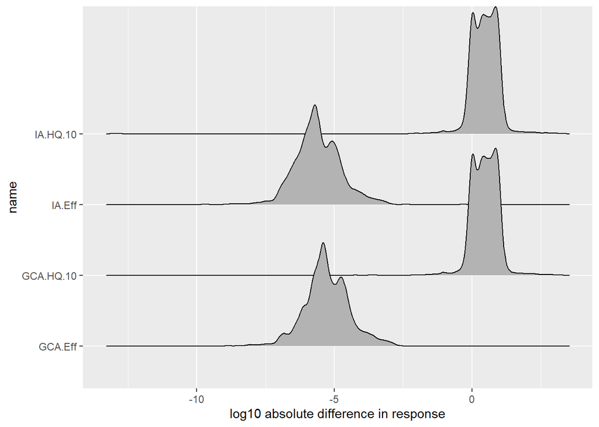

```r
# For the 1 day resolution
ggplot(tidyr::pivot_longer(data.table(time_resolution_mixture_response$`1`[[1]])[, lapply(.SD, function(t) {abs(diff(t))}), .SDcols = 2:5][, sample := 1:.N], cols = !sample) |>
         dplyr::filter(!is.na(value) & value >= 1E-15), aes(x = log10(value), y = name)) +
  ggridges::geom_density_ridges() +
  xlab('log10 absolute difference in response')
```

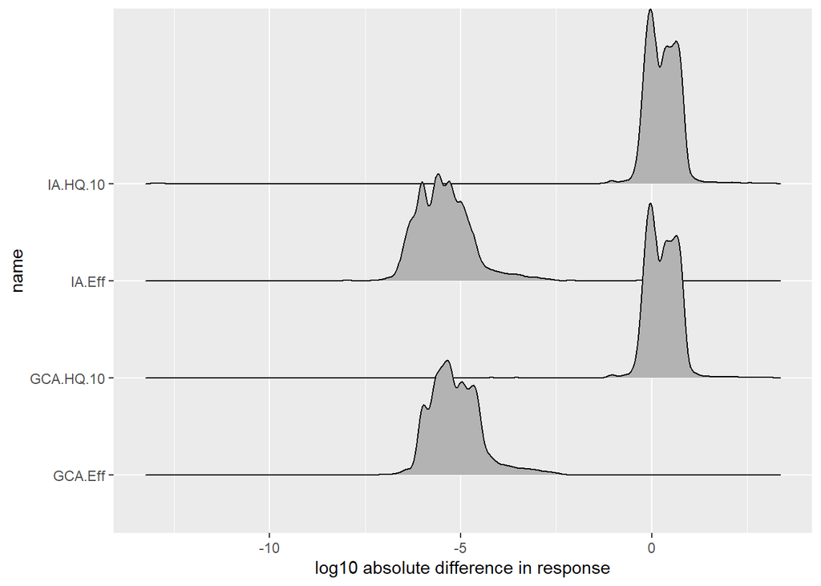

```r
# For the 2 day resolution
ggplot(tidyr::pivot_longer(data.table(time_resolution_mixture_response$`2`[[1]])[, lapply(.SD, function(t) {abs(diff(t))}), .SDcols = 2:5][, sample := 1:.N], cols = !sample) |>
         dplyr::filter(!is.na(value) & value >= 1E-15), aes(x = log10(value), y = name)) +
  ggridges::geom_density_ridges() +
  xlab('log10 absolute difference in response')
```

And again we examine the signed versions.

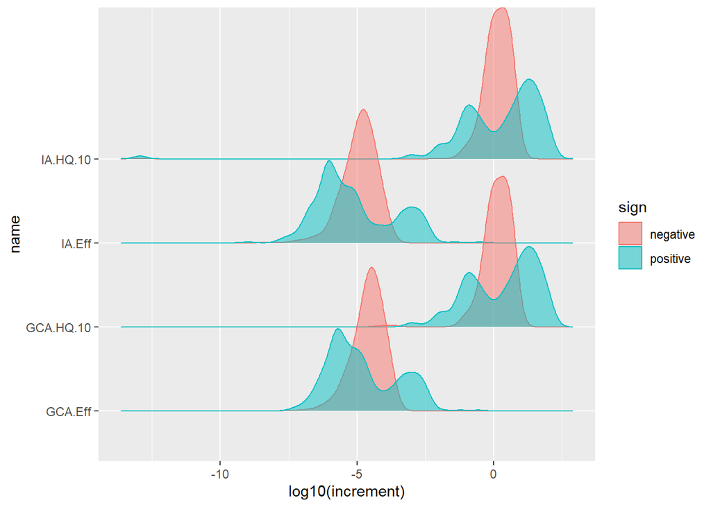

```r
# Process the data
resolution_sensitivity_mixture_signed_0.1 <- tidyr::pivot_longer(data.table(time_resolution_mixture_response$`0.1`[[1]])[, lapply(.SD, diff), .SDcols = 2:5][, sample := 1:.N], cols = !sample) |>
  dplyr::mutate(increment = abs(value), sign = ifelse(value > 0, 'positive', 'negative')) |>
  dplyr::filter(!is.na(increment) & increment >= 1E-15)

resolution_sensitivity_mixture_signed_1 <- tidyr::pivot_longer(data.table(time_resolution_mixture_response$`1`[[1]])[, lapply(.SD, diff), .SDcols = 2:5][, sample := 1:.N], cols = !sample) |>
  dplyr::mutate(increment = abs(value), sign = ifelse(value > 0, 'positive', 'negative')) |>
  dplyr::filter(!is.na(increment) & increment >= 1E-15)

resolution_sensitivity_mixture_signed_2 <- tidyr::pivot_longer(data.table(time_resolution_mixture_response$`2`[[1]])[, lapply(.SD, diff), .SDcols = 2:5][, sample := 1:.N], cols = !sample) |>
  dplyr::mutate(increment = abs(value), sign = ifelse(value > 0, 'positive', 'negative')) |>
  dplyr::filter(!is.na(increment) & increment >= 1E-15)

# Plot the data
ggplot(resolution_sensitivity_mixture_signed_0.1, aes(x = log10(increment), y = name, color = sign, fill = sign)) + ggridges::geom_density_ridges(alpha = .5)
```

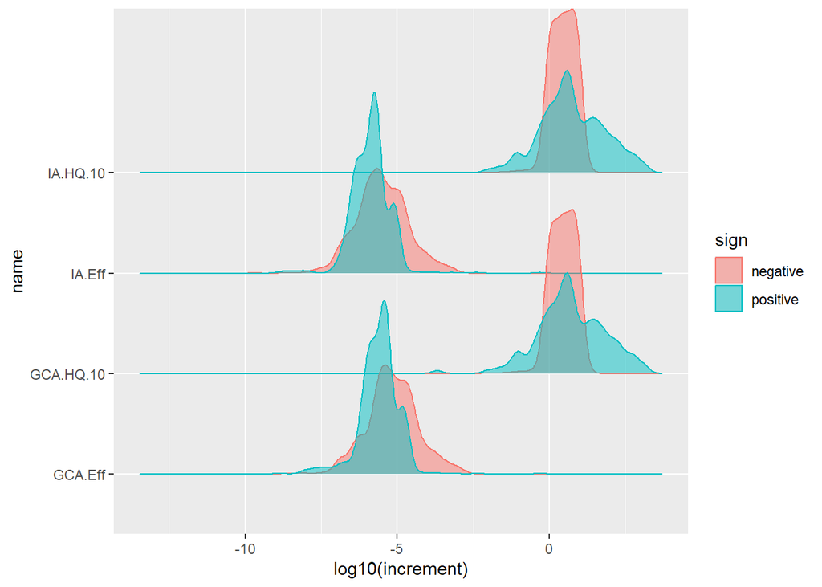

```r
ggplot(resolution_sensitivity_mixture_signed_1, aes(x = log10(increment), y = name, color = sign, fill = sign)) + ggridges::geom_density_ridges(alpha = .5)
```

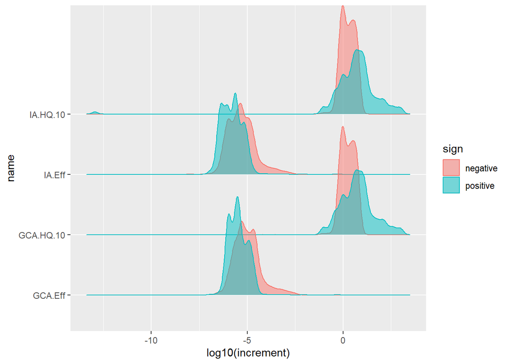

```r
ggplot(resolution_sensitivity_mixture_signed_2, aes(x = log10(increment), y = name, color = sign, fill = sign)) + ggridges::geom_density_ridges(alpha = .5)
```